# K-means_Clustering_STUDY

Umberto Fasci

3/25/2021

This initial study will focus on the utilization of the tidymodels package.

**K-means** clustering will act as an example to introduce several tidying functions in this document.

- tidy()
- augment()
- glance()

In fact, I have used these three functions in a recent workthrough provided by Julia Silge.

##Generate Data

This study starts by generating random two-dimensional data with three clusters. The data in each cluster will come from a **mulivariate gaussian distribution**, with different means for each cluster:

```r
library(tidymodels)
```

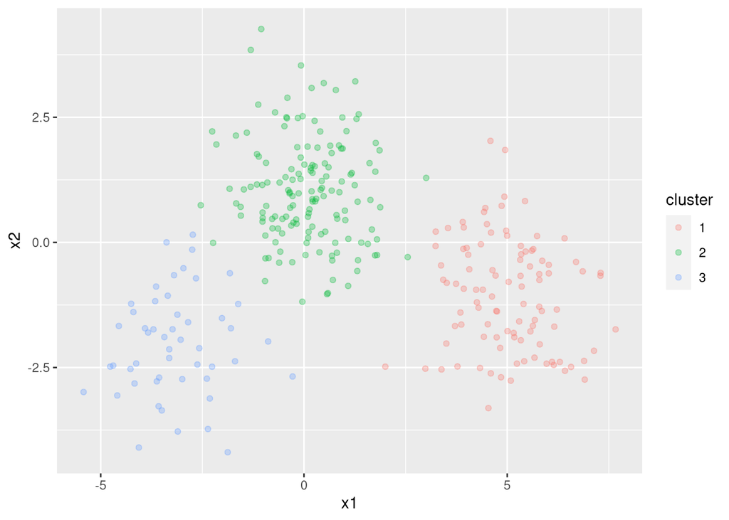

```r
set.seed(27)

centers <- tibble(
  cluster = factor(1:3),
  num_points = c(100, 150, 50), # number of points in each cluster
  x1 = c(5, 0, -3),             # x1 coordinate of cluster center
  x2 = c(-1, 1, -2)             # x2 coordinate of cluster center
)

labelled_points <-
  centers %>%
  mutate(
    x1 = map2(num_points, x1, rnorm), # generating multivariate normal random var.
    x2 = map2(num_points, x2, rnorm)
  ) %>%
  select(-num_points) %>%
  unnest(cols = c(x1, x2))

ggplot(labelled_points, aes(x1, x2, color = cluster)) +
  geom_point(alpha = 0.3)
```

Notice the distinct group separation. This is an ideal case for k-means clustering.

## How Does K-Means Work? (Initial Finding)

From what can be seen above, K-means takes data points as input and groups them into k clusters; in this case k = 3. Basically, as a clustering algorithm it can take new data and cluster it appropriately by measuring the euclidean distance between points as a measure of a similarity.

## Clustering in R

The next function to introduce the **kmeans()** function, ehich accepts a data frame with all numeric columns as it’s primary argument.

```r
points <-
  labelled_points %>%
  select(-cluster)

kclust <- kmeans(points, centers = 3)
kclust
```

```
## K-means clustering with 3 clusters of sizes 148, 51, 101
##
## Cluster means:
##            x1        x2
## 1  0.08853475  1.045461
## 2 -3.14292460 -2.000043
## 3  5.00401249 -1.045811
##
## Clustering vector:
##   [1] 3 3 3 3 3 3 3 3 3 3 3 3 3 3 3 3 3 3 3 3 3 3 3 3 3 3 3 3 3 3 3 3 3 3 3 3 3
##  [38] 3 3 3 3 3 3 3 3 3 3 3 3 3 3 3 3 3 3 3 3 3 3 3 3 3 3 3 3 3 3 3 3 3 3 3 3 3
##  [75] 3 3 3 3 3 3 3 3 3 3 3 3 3 3 3 3 3 3 3 3 3 3 3 3 3 3 1 1 1 1 1 1 1 1 1 1 1
## [112] 1 1 1 1 1 1 1 1 1 1 1 1 1 1 1 1 1 1 1 1 1 1 1 1 1 1 1 1 1 1 1 1 1 1 1 1 1
## [149] 1 1 1 1 1 1 1 1 1 1 1 1 1 1 1 1 1 1 1 1 1 1 1 1 1 1 1 1 1 1 1 1 1 1 1 1 1
## [186] 1 1 1 1 1 1 1 1 1 1 1 1 1 3 1 1 1 1 1 1 1 1 1 1 1 1 1 1 1 1 1 1 1 1 1 1 1
## [223] 1 1 1 1 1 1 1 1 1 1 1 1 1 1 1 1 1 1 1 1 1 2 1 1 1 1 1 1 2 2 2 2 2 2 2 2 2
## [260] 2 2 2 2 2 2 2 2 2 2 2 2 2 2 2 2 2 2 2 2 2 2 2 2 2 2 2 2 2 2 2 2 2 2 2 2 2
## [297] 2 2 2 2
##
## Within cluster sum of squares by cluster:
## [1] 298.9415 108.8112 243.2092
##  (between_SS / total_SS =  82.5 %)
##
## Available components:
##
## [1] "cluster"      "centers"      "totss"        "withinss"     "tot.withinss"
## [6] "betweenss"    "size"         "iter"         "ifault"
```

```r
summary(kclust)
```

```
##              Length Class  Mode
## cluster      300    -none- numeric
## centers        6    -none- numeric
## totss          1    -none- numeric
## withinss       3    -none- numeric
## tot.withinss   1    -none- numeric
## betweenss      1    -none- numeric
## size           3    -none- numeric
## iter           1    -none- numeric
## ifault         1    -none- numeric
```

```r
augment(kclust, points)
```

```
## # A tibble: 300 x 3
##       x1     x2 .cluster
##    <dbl>  <dbl> <fct>
##  1  6.91 -2.74  3
##  2  6.14 -2.45  3
##  3  4.24 -0.946 3
##  4  3.54  0.287 3
##  5  3.91  0.408 3
##  6  5.30 -1.58  3
##  7  5.01 -1.77  3
##  8  6.16 -1.68  3
##  9  7.13 -2.17  3
## 10  5.24 -2.42  3
## # … with 290 more rows
```

Summarizing on a per-cluister level (3 clusters here)

```r
tidy(kclust)
```

```
## # A tibble: 3 x 5
##        x1    x2  size withinss cluster
##     <dbl> <dbl> <int>    <dbl> <fct>
## 1  0.0885  1.05   148     299. 1
## 2 -3.14   -2.00    51     109. 2
## 3  5.00   -1.05   101     243. 3
```

Extract a single row summary with the glance() function.

```r
glance(kclust)
```

```
## # A tibble: 1 x 4
##   totss tot.withinss betweenss  iter
##   <dbl>        <dbl>     <dbl> <int>
## 1 3724.         651.     3073.     2
```

## Exploratory Clustering

Let’s explore the effect of different choices of k, from 1 to 9.

First, let’s cluster the data 9 times, each using a different value of k, then we can create columns containing the tidied, glanced, and augmented data for comparisons.

```r
kclusts <-
  tibble(k = 1:9) %>%
  mutate(
    kclust = map(k, ~kmeans(points, .x)),
    tidied = map(kclust, tidy),
    glanced = map(kclust, glance),
    augmented = map(kclust, augment, points)
  )
kclusts
```

```
## # A tibble: 9 x 5
##       k kclust   tidied           glanced          augmented
##   <int> <list>   <list>           <list>           <list>
## 1     1 <kmeans> <tibble [1 × 5]> <tibble [1 × 4]> <tibble [300 × 3]>
## 2     2 <kmeans> <tibble [2 × 5]> <tibble [1 × 4]> <tibble [300 × 3]>
## 3     3 <kmeans> <tibble [3 × 5]> <tibble [1 × 4]> <tibble [300 × 3]>
## 4     4 <kmeans> <tibble [4 × 5]> <tibble [1 × 4]> <tibble [300 × 3]>
## 5     5 <kmeans> <tibble [5 × 5]> <tibble [1 × 4]> <tibble [300 × 3]>
## 6     6 <kmeans> <tibble [6 × 5]> <tibble [1 × 4]> <tibble [300 × 3]>
## 7     7 <kmeans> <tibble [7 × 5]> <tibble [1 × 4]> <tibble [300 × 3]>
## 8     8 <kmeans> <tibble [8 × 5]> <tibble [1 × 4]> <tibble [300 × 3]>
## 9     9 <kmeans> <tibble [9 × 5]> <tibble [1 × 4]> <tibble [300 × 3]>
```

Now lets separate these into individual datasets using tidy(), augment(), and glance().

```r
clusters <-
  kclusts %>%
  unnest(cols = c(tidied))

assignments <-
  kclusts %>%
  unnest(cols = c(augmented))

clusterings <-
  kclusts %>%
  unnest(cols = c(glanced))
```

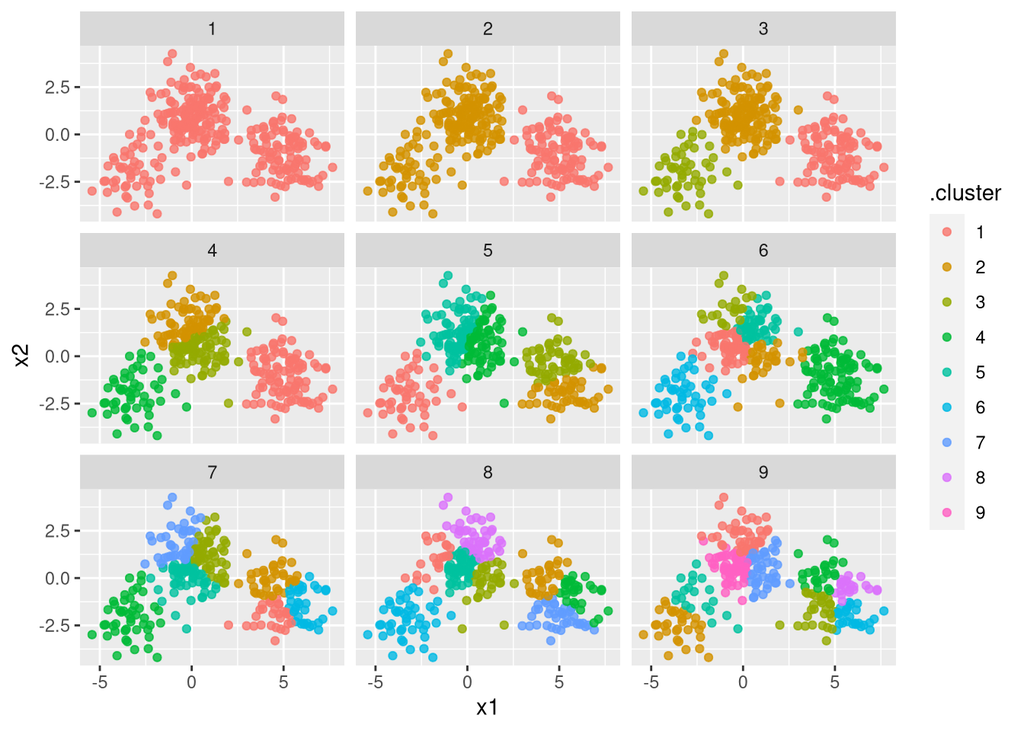

```r
p1 <-
  ggplot(assignments, aes(x = x1, y = x2)) +
  geom_point(aes(color = .cluster), alpha = 0.8) +
  facet_wrap(~ k)
p1
```

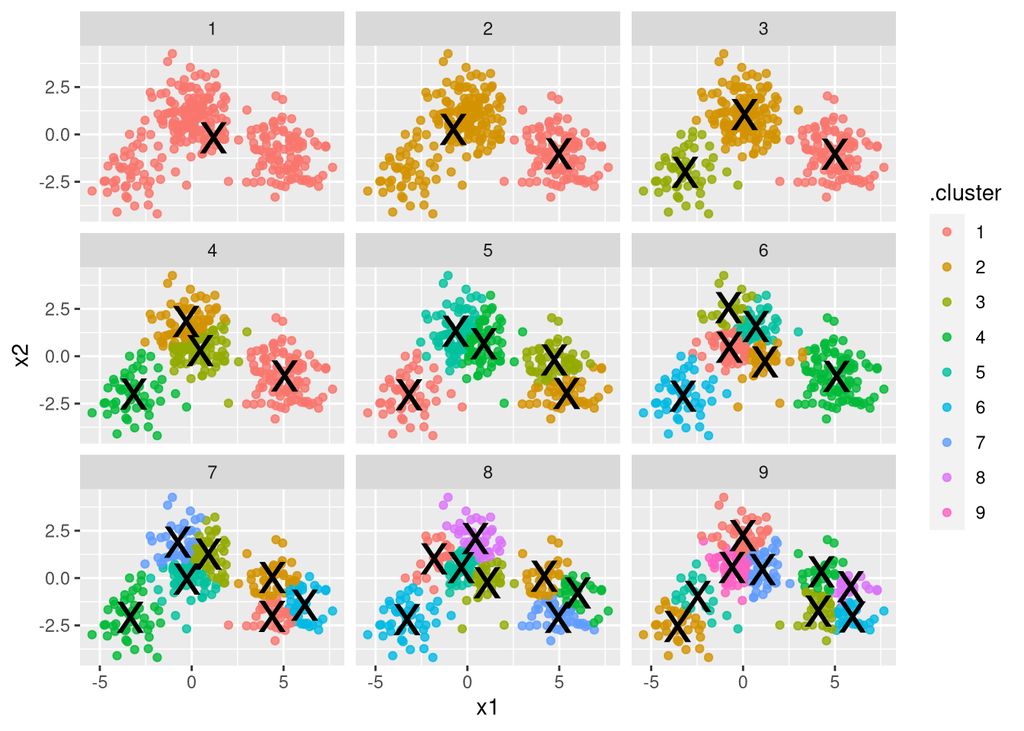

```r
p2 <- p1 + geom_point(data = clusters, size = 10, shape = "x")
p2
```

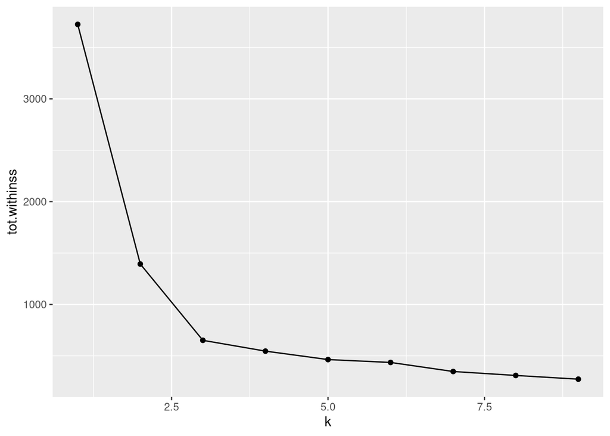

```r
ggplot(clusterings, aes(k, tot.withinss)) +
  geom_line() +
  geom_point()
```